# PSY 8960 Week 8 Project

Anthony Greco

2023-03-19

# **Reproducible Image and Online Resources**

An image of this project as of *2023-03-19* can be accessed by [clicking this link](https://mybinder.org/v2/gh/agreco003/psy8960-week8/HEAD). An interactive web app is available by [clicking this link instead.](https://agreco003.shinyapps.io/shiny_week8/)

# **Script Settings and Resources**

```r
setwd(dirname(rstudioapi::getActiveDocumentContext()$path))
library(tidyverse)
```

# **Data Import and Cleaning**

Data cleaned to recast condition and gender as factors, timestamps as POSIX, reverse code q5, and create mean values of q1:q6 and q7:q10. This makes the tibble easier to interpret, more consistent, and coded accurately for future analyses and visualizations. Past data cleaning efforts beyond this scope (dropping all cases that did not answer 1 on q6) were not included because they were noted in this project.

```r
week8_tbl <- read_csv(file ="../data/week3.csv") %>%
  mutate(condition = factor(condition, levels = c("A", "B", "C"), labels = c("Block A", "Block B", "Control")),
         gender = factor(gender, levels = c("M", "F"), labels = c("Male", "Female")),
         q5 = case_match(q5, 1 ~ 5, 2 ~ 4, 3 ~ 3, 4 ~ 2, 5 ~ 1),
         timeStart = ymd_hms(timeStart),
         q1_q6_mean = rowMeans(across(q1:q6)),
         q7_q10_mean = rowMeans(across(q7:q10)))
```

# **Visualization**

Below is a paginated table for variables Q1 - Q6, followed by a scatter plot that examines the relationship between the mean values of Q1-Q6 and the mean values of Q7 - Q10.

|  | q1 | q2 | q3 | q4 | q5 | q6 |
| --- | --- | --- | --- | --- | --- | --- |
| 1 | 5 | 4 | 4 | 1 | 2 | 1 |
| 2 | 2 | 4 | 3 | 1 | 3 | 1 |
| 3 | 5 | 5 | 2 | 1 | 5 | 1 |
| 4 | 4 | 3 | 4 | 2 | 4 | 1 |
| 5 | 3 | 1 | 3 | 5 | 2 | 1 |
| 6 | 4 | 3 | 2 | 3 | 3 | 1 |
| 7 | 2 | 4 | 1 | 3 | 1 | 1 |
| 8 | 4 | 2 | 5 | 1 | 1 | 1 |
| 9 | 2 | 5 | 3 | 4 | 2 | 1 |
| 10 | 3 | 4 | 2 | 4 | 5 | 1 |

[output cut: 39 more lines]

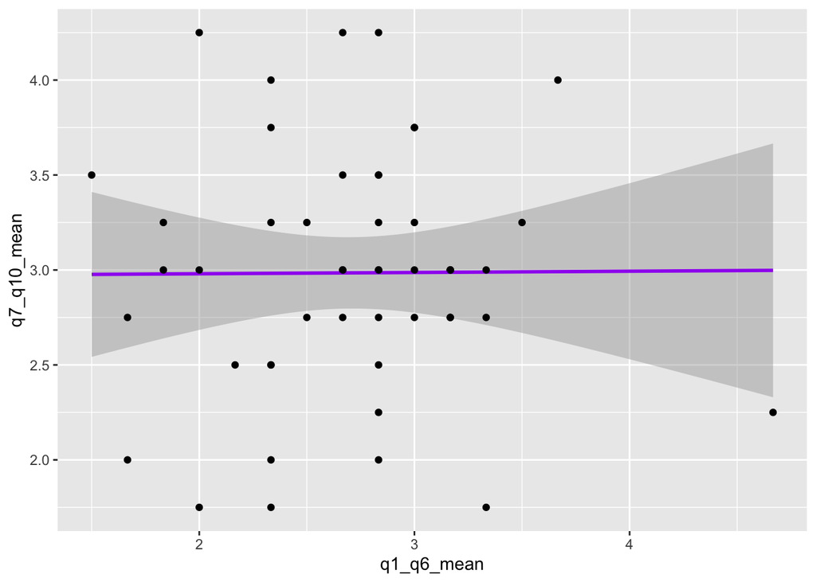

# **Analysis**

The results of a correlation test can aide in the interpretation of those results.

```
##
##  Pearson's product-moment correlation
##
## data:  week8_tbl$q1_q6_mean and week8_tbl$q7_q10_mean
## t = 0.041376, df = 47, p-value = 0.9672
## alternative hypothesis: true correlation is not equal to 0
## 95 percent confidence interval:
##  -0.2756291  0.2867452
## sample estimates:
##         cor
## 0.006035238
```

I observed a correlation of 0.0060352, which is not statistically significant. This suggests no relationship between these variables.

# **Data Export**

Finally, an export of the necessary data was created for the interactive shiny app found above.

```r
(week8_df <- select(week8_tbl, all_of(c("gender", "q1_q6_mean", "q7_q10_mean", "timeStart")))) %>%
saveRDS(file = "../shiny/shiny_week8/week8.rds")
```